# IE582_fall-23/HW_3

Bisher Allaham

20/01/2024

Generating the data: 4 different settings, 8 variables, 2000 data points in total

```r
library(MASS)
# Set the seed for reproducibility
set.seed(102)

# Number of data points per set
num_points_per_set <- 500

# Number of variables
num_variables <- 8

# Number of different parameter settings (sets)
num_settings <- 4

# Initialize an empty matrix to store the data
data <- matrix(0, nrow = num_points_per_set * num_settings, ncol = num_variables)

# Initialize a vector to store labels
labels <- character(num_points_per_set * num_settings)

# Loop through each parameter setting (set)
for (setting in 1:num_settings) {
  # Generate mean values for each variable with a larger separation between sets
  means <- runif(num_variables, min = 8 * setting, max = 8 * (setting + 1))

  # Generate a covariance matrix
  cov_matrix <- matrix(runif(num_variables^2), nrow = num_variables)

  # Ensure the covariance matrix is symmetric and positive definite
  cov_matrix <- 0.5 * (cov_matrix + t(cov_matrix)) + num_variables * diag(num_variables)

  # Generate data points for the current setting
  current_data <- mvrnorm(n = num_points_per_set, mu = means, Sigma = cov_matrix)

  # Add the generated data to the main matrix
  data[((setting - 1) * num_points_per_set + 1):(setting * num_points_per_set), ] <- current_data
  # Assign labels to the data points
  labels[((setting - 1) * num_points_per_set + 1):(setting * num_points_per_set)] <- paste("Set", setting, "_Point", 1:num_points_per_set)
}
```

```r
# Convert the matrix to a data frame
data_df <- as.data.frame(data)

# Add labels to the data frame
data_df$labels <- labels

# Display the structure of the data frame
str(data_df)
```

```
## 'data.frame':    2000 obs. of  9 variables:
##  $ V1    : num  15.19 17.49 14.7 5.24 12.13 ...
##  $ V2    : num  5.59 14.44 10.26 8.2 15.5 ...
##  $ V3    : num  10.57 12.62 13.14 6.57 9.41 ...
##  $ V4    : num  12.55 6.75 9.29 11.6 10.71 ...
##  $ V5    : num  8.17 7.41 9.43 4.69 9.3 ...
##  $ V6    : num  5.53 13.86 13.48 12.44 11.52 ...
##  $ V7    : num  16.7 16.75 16.77 6.06 15.91 ...
##  $ V8    : num  5.58 10.9 10.29 13.05 8.6 ...
##  $ labels: chr  "Set 1 _Point 1" "Set 1 _Point 2" "Set 1 _Point 3" "Set 1 _Point 4" ...
```

Here I plotted the data, 2 variables at a time

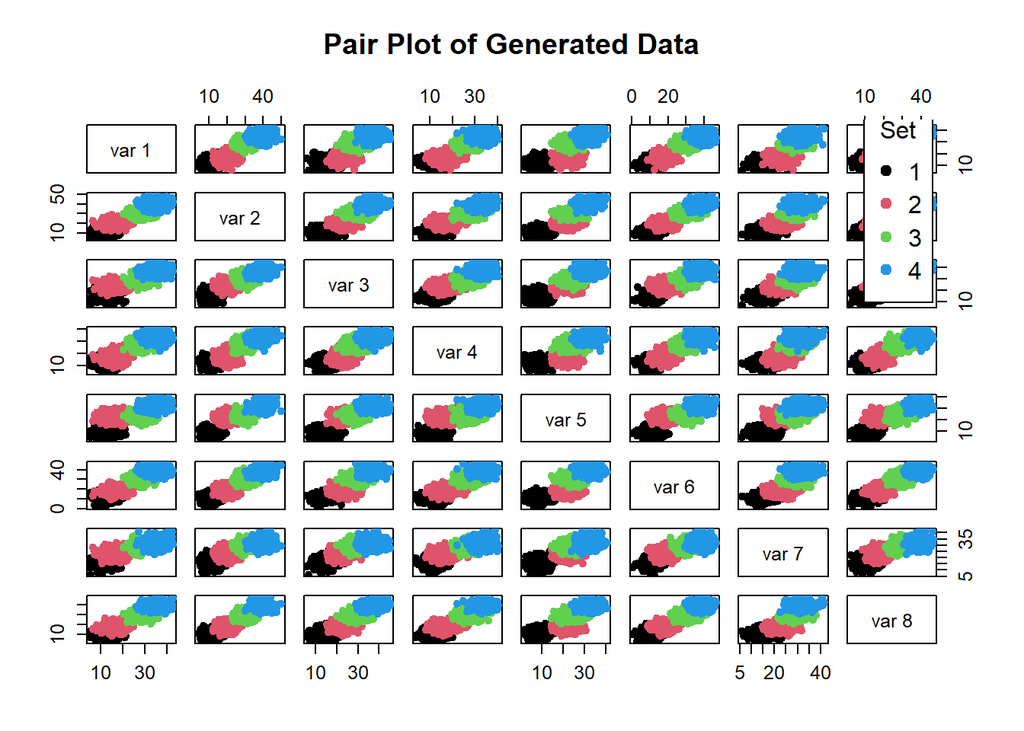

```r
# Plot the pair plot
pairs(data, col = rep(1:num_settings, each = num_points_per_set),
      pch = 19, main = "Pair Plot of Generated Data",
      cex.labels = 1.2, cex.axis = 1.2)

# Add a legend
legend("topright", legend = 1:num_settings, col = 1:num_settings, pch = 19, title = "Set")
```

This part is to visualize the data after partitioning using k-means

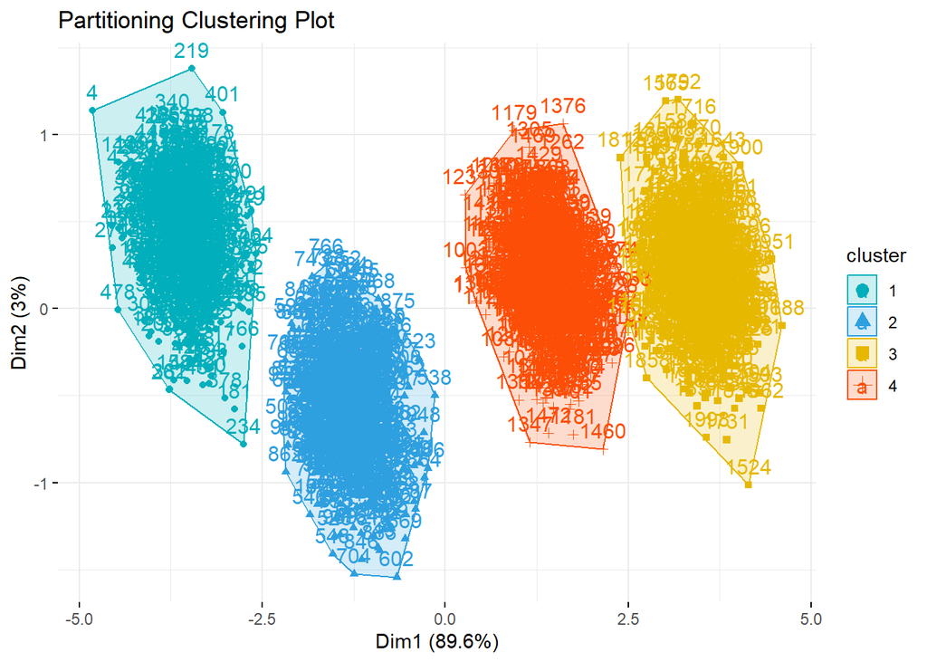

```r
require("ggplot2")
require("factoextra")
require("cluster")
require("data.table")
# 2. Compute k-means
set.seed(123)
km.res <- kmeans(data, 4, nstart = 500)
# 3. Visualize
fviz_cluster(km.res, data,
             palette = c("#00AFBB","#2E9FDF", "#E7B800", "#FC4E07"),
             ggtheme = theme_minimal(),
             main = "Partitioning Clustering Plot"
             )
```

This is PAM method for clustering

```r
library(randomForest)
```

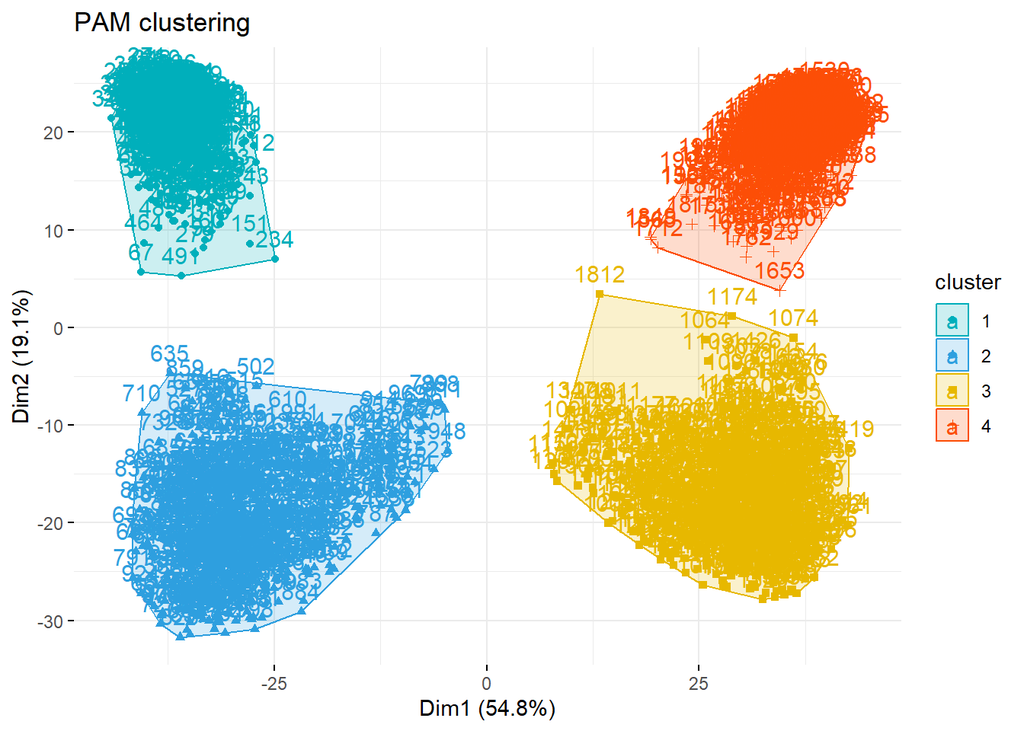

```r
# Train random forest for clustering
rf_model <- randomForest(data_df, ntree = 2000, mtry = 2, proximity = TRUE)
# Extract proximity matrix
prox_matrix <- rf_model$proximity

suppressPackageStartupMessages(library(cluster))
pam.rf <- pam(prox_matrix, 4)
pred <- cbind(pam.rf$clustering, data_df$labels)
fviz_cluster(pam.rf, data,
             palette = c("#00AFBB","#2E9FDF", "#E7B800", "#FC4E07"),
             ggtheme = theme_minimal(),
             main = "PAM clustering"
             )
```

I left here..

```r
library(randomForest)

rf_data <- randomForest(x = data, mtry = 2, ntree = 2000, proximity = TRUE)

# Output information about the trained model
rf_data
```

```
##
## Call:
##  randomForest(x = data, ntree = 2000, mtry = 2, proximity = TRUE)
##                Type of random forest: unsupervised
##                      Number of trees: 2000
## No. of variables tried at each split: 2
```

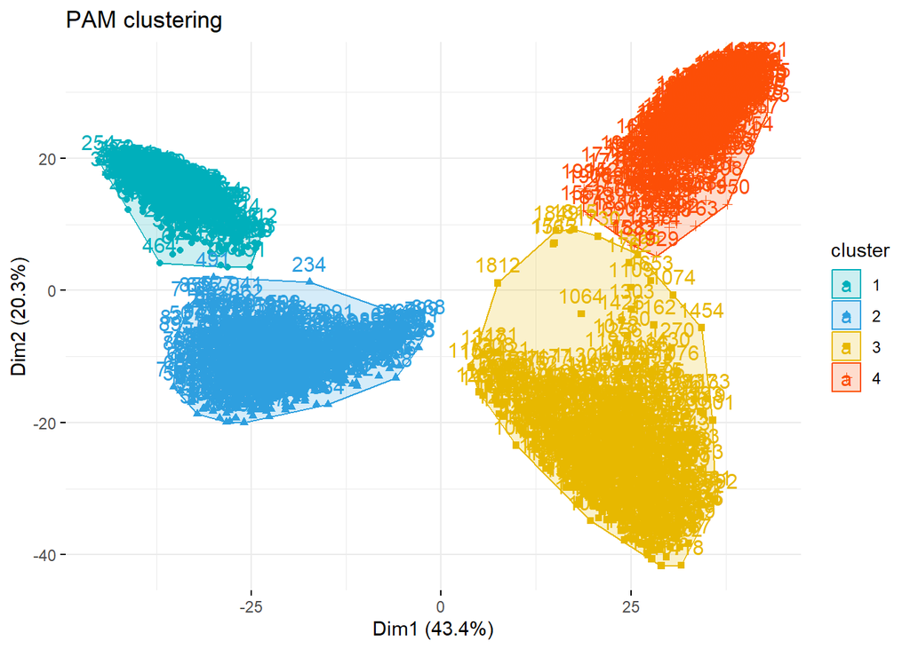

```r
# proximity
prox <- rf_data$proximity
# Convert proximity values to dissimilarity
dissimilarity_matrix <- sqrt(1 - prox)
# Partitioning Around Medoids (PAM)
pam.rf2 <- pam(dissimilarity_matrix, 4)
# visualize with a graph
fviz_cluster(pam.rf2, data,
             palette = c("#00AFBB","#2E9FDF", "#E7B800", "#FC4E07"),
             ggtheme = theme_minimal(),
             main = "PAM clustering"
             )
```

here I tried hierarchical clustering with ward method

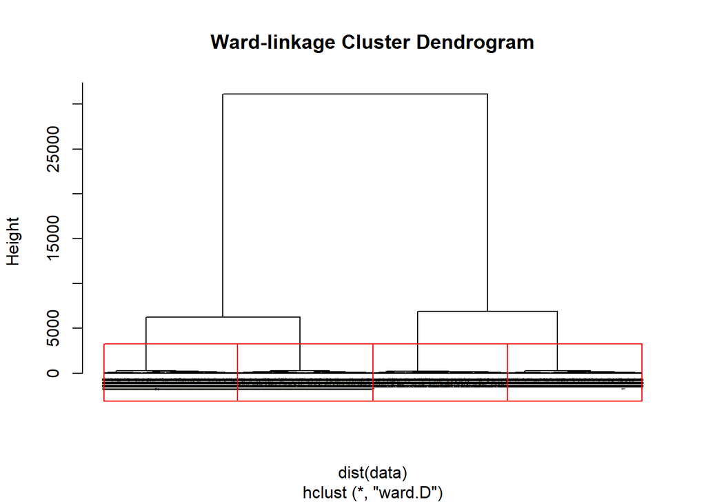

```r
sol = hclust(dist(data), method = "ward.D")

plot(sol,cex = 0.3,hang = - 10, main = "Ward-linkage Cluster Dendrogram")
rect.hclust(sol, k=4, border="red")
```

```r
cluster_id = cutree(as.hclust(sol), k = 4)
table(cluster_id)
```

```
## cluster_id
##   1   2   3   4
## 500 500 504 496
```

```r
data_cluster = data.frame(cluster_id)
tmp=cbind(cluster_id=data_cluster$cluster_id,data)
```

computing sample mean and cov matrix of each cluster

```r
# Hierarchical Clustering
cluster_id_hc <- cutree(as.hclust(sol), k = 4)

# Partitioning Around Medoids (PAM)
cluster_id_pam <- pam.rf2$clustering

# K-means Clustering
cluster_id_kmeans <- km.res$cluster


# Function to compute sample mean vector and covariance matrix for each cluster
compute_cluster_stats <- function(data, cluster_id) {
  unique_clusters <- unique(cluster_id)
  num_clusters <- length(unique_clusters)

  cluster_means <- matrix(0, nrow = num_clusters, ncol = ncol(data))
  cluster_covs <- array(0, dim = c(ncol(data), ncol(data), num_clusters))

  for (i in 1:num_clusters) {
    cluster_data <- data[cluster_id == unique_clusters[i], ]
    cluster_means[i, ] <- colMeans(cluster_data, na.rm = TRUE)
    cluster_covs[, , i] <- cov(cluster_data, use = "pairwise")
  }

  list(cluster_means = cluster_means, cluster_covs = cluster_covs)
}

# Compute cluster statistics for hierarchical clustering
stats_hc <- compute_cluster_stats(data, cluster_id_hc)

# Compute cluster statistics for PAM
stats_pam <- compute_cluster_stats(data, cluster_id_pam)

# Compute cluster statistics for k-means
stats_kmeans <- compute_cluster_stats(data, cluster_id_kmeans)

# Print the computed statistics
print("Hierarchical Clustering:")
```

```
## [1] "Hierarchical Clustering:"
```

```r
print(stats_hc)
```

```
## $cluster_means
##          [,1]     [,2]     [,3]     [,4]      [,5]     [,6]     [,7]     [,8]
## [1,] 12.78423 11.91775 14.33299 12.22346  8.850318 11.40033 15.84316 10.75279
## [2,] 16.11039 20.02339 23.45021 16.89478 22.025529 18.53327 23.25058 17.66447
## [3,] 28.93572 30.67413 29.44847 27.89801 24.556345 31.01503 29.69945 28.92727
## [4,] 35.28991 39.97556 37.33486 33.81447 32.356304 38.51478 31.72576 38.92450
##
## $cluster_covs
## , , 1
##
##             [,1]        [,2]       [,3]        [,4]        [,5]      [,6]
## [1,]  8.31667472  0.55770623  0.4937222  0.02442486  0.67230769 0.6465308
## [2,]  0.55770623  7.56569986  0.2071687  0.32494600  0.36671527 0.7441026
## [3,]  0.49372224  0.20716871  8.3963775  0.90821962 -0.16784340 0.4623550
## [4,]  0.02442486  0.32494600  0.9082196  7.93939010 -0.01369611 0.5983597
```

[output cut: 76 more lines]

```r
print("\nPAM:")
```

```
## [1] "\nPAM:"
```

```r
print(stats_pam)
```

```
## $cluster_means
##          [,1]     [,2]     [,3]     [,4]      [,5]     [,6]     [,7]     [,8]
## [1,] 12.79544 11.91562 14.32455 12.20767  8.841513 11.37394 15.81679 10.74370
## [2,] 16.08602 19.99321 23.42226 16.89184 21.981773 18.53103 23.24723 17.64595
## [3,] 28.96805 30.76348 29.50567 27.90229 24.598563 31.10392 29.61046 29.03258
## [4,] 35.30818 39.95892 37.33992 33.85816 32.376128 38.48397 31.83413 38.89705
##
## $cluster_covs
## , , 1
##
##             [,1]        [,2]       [,3]        [,4]        [,5]      [,6]
## [1,]  8.28001623 0.519788547  0.5157231  0.08315526  0.74263715 0.6898735
## [2,]  0.51978855 7.539882828  0.1990671  0.33486714  0.41474179 0.6931357
## [3,]  0.51572308 0.199067121  8.4119449  0.87983045 -0.18302208 0.4051874
## [4,]  0.08315526 0.334867136  0.8798304  7.90357801 -0.06442044 0.5086876
```

[output cut: 76 more lines]

```r
print("\nK-Means:")
```

```
## [1] "\nK-Means:"
```

```r
print(stats_kmeans)
```

```
## $cluster_means
##          [,1]     [,2]     [,3]     [,4]      [,5]     [,6]     [,7]     [,8]
## [1,] 12.78423 11.91775 14.33299 12.22346  8.850318 11.40033 15.84316 10.75279
## [2,] 16.11039 20.02339 23.45021 16.89478 22.025529 18.53327 23.25058 17.66447
## [3,] 28.89099 30.65479 29.41363 27.85684 24.508910 30.97629 29.67330 28.88735
## [4,] 35.28380 39.92048 37.30662 33.80831 32.341340 38.49353 31.73570 38.88444
##
## $cluster_covs
## , , 1
##
##             [,1]        [,2]       [,3]        [,4]        [,5]      [,6]
## [1,]  8.31667472  0.55770623  0.4937222  0.02442486  0.67230769 0.6465308
## [2,]  0.55770623  7.56569986  0.2071687  0.32494600  0.36671527 0.7441026
## [3,]  0.49372224  0.20716871  8.3963775  0.90821962 -0.16784340 0.4623550
## [4,]  0.02442486  0.32494600  0.9082196  7.93939010 -0.01369611 0.5983597
```

[output cut: 76 more lines]

Adding noise variables

```r
# Number of noise variables
num_noise_variables <- 8

# Generate random binary noise variables from a Bernoulli distribution
noise_variables <- matrix(rbinom(n = nrow(data) * num_noise_variables, size = 1, prob = 0.5), ncol = num_noise_variables)

# Combine the original data with the binary noise variables
data_with_noise <- cbind(data, noise_variables)

# Display the structure of the new data
str(data_with_noise)
```

```
##  num [1:2000, 1:16] 15.19 17.49 14.7 5.24 12.13 ...
```

do the clustering for the new data using the three models (k-means, PAM, hclust-ward)

```r
# finding proximity using random forest
rf_data2 <- randomForest(x = data_with_noise, mtry = 2, ntree = 2000, proximity = TRUE)
# proximity
prox2 <- rf_data2$proximity
# Convert proximity values to dissimilarity
dissimilarity_matrix2 <- sqrt(1 - prox2)

km.res <- kmeans(data_with_noise, 4, nstart = 500)
pam.rf <- pam(dissimilarity_matrix2, 4)
sol = hclust(dist(data_with_noise), method = "ward.D")

#
# Hierarchical Clustering
cluster_id_hc <- cutree(as.hclust(sol), k = 4)

# Partitioning Around Medoids (PAM)
cluster_id_pam <- pam.rf$clustering

# K-means Clustering
cluster_id_kmeans <- km.res$cluster

# Compute cluster statistics for hierarchical clustering
stats_hc <- compute_cluster_stats(data_with_noise, cluster_id_hc)

# This function is defined in the previous chunk
# Compute cluster statistics for PAM
stats_pam <- compute_cluster_stats(data_with_noise, cluster_id_pam)

# Compute cluster statistics for k-means
stats_kmeans <- compute_cluster_stats(data_with_noise, cluster_id_kmeans)

# Print the computed statistics
print("Hierarchical Clustering:")
```

```
## [1] "Hierarchical Clustering:"
```

```r
print(stats_hc)
```

```
## $cluster_means
##          [,1]     [,2]     [,3]     [,4]      [,5]     [,6]     [,7]     [,8]
## [1,] 12.78423 11.91775 14.33299 12.22346  8.850318 11.40033 15.84316 10.75279
## [2,] 16.11039 20.02339 23.45021 16.89478 22.025529 18.53327 23.25058 17.66447
## [3,] 28.88305 30.63667 29.43430 27.88505 24.498697 30.99669 29.67704 28.88158
## [4,] 35.29173 39.93861 37.28594 33.78010 32.351553 38.47312 31.73197 38.89021
##       [,9] [,10] [,11] [,12] [,13] [,14] [,15] [,16]
## [1,] 0.512 0.512 0.486 0.524 0.504 0.502 0.530 0.484
## [2,] 0.484 0.496 0.496 0.486 0.478 0.508 0.498 0.508
## [3,] 0.498 0.488 0.532 0.472 0.480 0.516 0.482 0.490
## [4,] 0.506 0.462 0.500 0.484 0.568 0.504 0.510 0.454
##
## $cluster_covs
## , , 1
##
```

[output cut: 281 more lines]

```r
print("\nPAM:")
```

```
## [1] "\nPAM:"
```

```r
print(stats_pam)
```

```
## $cluster_means
##          [,1]     [,2]     [,3]     [,4]      [,5]     [,6]     [,7]     [,8]
## [1,] 12.75512 11.85869 14.17970 12.05884  8.813313 11.23576 15.62792 10.52726
## [2,] 16.34323 19.67253 22.77828 16.99771 20.738789 18.48411 22.91323 17.57509
## [3,] 28.87642 30.93628 29.78373 27.84814 24.891057 31.01898 29.52417 29.23208
## [4,] 35.37351 39.94234 37.36611 33.92552 32.408820 38.56397 31.85654 38.89285
##           [,9]     [,10]     [,11]     [,12]     [,13]     [,14]     [,15]
## [1,] 0.5694761 0.4988610 0.5398633 0.5102506 0.5239180 0.5398633 0.5102506
## [2,] 0.4101222 0.5113438 0.4188482 0.4904014 0.4938918 0.4746946 0.4834206
## [3,] 0.5230769 0.5057692 0.5750000 0.4692308 0.4230769 0.5211538 0.5326923
## [4,] 0.5192308 0.4358974 0.4935897 0.5000000 0.6025641 0.5021368 0.4957265
##          [,16]
## [1,] 0.4464692
## [2,] 0.5008726
## [3,] 0.5461538
```

[output cut: 252 more lines]

```r
print("\nK-Means:")
```

```
## [1] "\nK-Means:"
```

```r
print(stats_kmeans)
```

```
## $cluster_means
##          [,1]     [,2]     [,3]     [,4]      [,5]     [,6]     [,7]     [,8]
## [1,] 12.78423 11.91775 14.33299 12.22346  8.850318 11.40033 15.84316 10.75279
## [2,] 16.11039 20.02339 23.45021 16.89478 22.025529 18.53327 23.25058 17.66447
## [3,] 28.89099 30.65479 29.41363 27.85684 24.508910 30.97629 29.67330 28.88735
## [4,] 35.28380 39.92048 37.30662 33.80831 32.341340 38.49353 31.73570 38.88444
##       [,9] [,10] [,11] [,12] [,13] [,14] [,15] [,16]
## [1,] 0.512 0.512 0.486 0.524 0.504 0.502 0.530 0.484
## [2,] 0.484 0.496 0.496 0.486 0.478 0.508 0.498 0.508
## [3,] 0.496 0.488 0.532 0.472 0.480 0.514 0.480 0.490
## [4,] 0.508 0.462 0.500 0.484 0.568 0.506 0.512 0.454
##
## $cluster_covs
## , , 1
##
```

[output cut: 281 more lines]